# Planning Shiny app

```r
library(tidyverse)
library(CodeClanData)
```

# explore data

Suggested: games

```r
game_sales <- CodeClanData::game_sales
```

```r
glimpse(game_sales)
```

```
Rows: 1,823
Columns: 10
$ name            <chr> "Wii Sports", "Mario Kart Wii", "Wii Sports Resort", "New Super Mario Bros.", "Wii Play", "New Super Mario Bro…
$ genre           <chr> "Sports", "Racing", "Sports", "Platform", "Misc", "Platform", "Racing", "Sports", "Sports", "Misc", "Puzzle", …
$ year_of_release <dbl> 2006, 2008, 2009, 2006, 2006, 2009, 2005, 2007, 2009, 2005, 2005, 2005, 2007, 2011, 2011, 2012, 2010, 2012, 20…
$ publisher       <chr> "Nintendo", "Nintendo", "Nintendo", "Nintendo", "Nintendo", "Nintendo", "Nintendo", "Nintendo", "Nintendo", "N…
$ sales           <dbl> 82.53, 35.52, 32.77, 29.80, 28.92, 28.32, 23.21, 22.70, 21.79, 20.15, 15.29, 12.13, 11.35, 10.81, 10.12, 9.90,…
$ critic_score    <dbl> 76, 82, 80, 89, 58, 87, 91, 80, 80, 77, 77, 86, 97, 90, 74, 78, 74, 88, 82, 88, 85, 97, 84, 85, 49, 85, 96, 95…
$ user_score      <dbl> 8.0, 8.3, 8.0, 8.5, 6.6, 8.4, 8.6, 7.7, 7.4, 7.9, 7.1, 8.7, 8.9, 8.4, 7.8, 7.2, 7.3, 8.7, 4.3, 6.6, 5.0, 9.1, …
$ developer       <chr> "Nintendo", "Nintendo", "Nintendo", "Nintendo", "Nintendo", "Nintendo", "Nintendo", "Nintendo", "Nintendo", "N…
$ rating          <chr> "E", "E", "E", "E", "E", "E", "E", "E", "E", "E", "E", "E", "E", "E", "E10+", "E", "E10+", "E", "E", "E", "E",…
$ platform        <chr> "Wii", "Wii", "Wii", "DS", "Wii", "Wii", "DS", "Wii", "Wii", "DS", "DS", "DS", "Wii", "3DS", "Wii", "3DS", "Wi…
```

# Planning concept & purpose

## Initial ideas

- Find top 10 rated (user_score - or critic_score, user option) games in a certain year range, colour it by the developer (or publisher <- option for user)
  - Show also the sales for same period.
  - Show also total sales by publisher or developer.
  - Show which publisher publishes which developer.
- show total sales, coloured by game, for each developer, by publisher (option) - i.e. assume i am a publisher and want to see how my developers are performing – dynamic inputlist depending on which publisher? (if poss)
- have a tab with the data loaded, and filters at the top for publisher, developer, game (name), platform
  - or just developer, platform, rating – assuming I am a publisher, looking to build my portfolio of which games to publish

## Understanding pub<->dev relationships

```r
developers
```

```
 [1] "Nintendo"                "Ubisoft"
 [3] "EA"                      "Namco"
 [5] "Capcom"                  "Traveller's Tales"
 [7] "Neversoft Entertainment" "Vicarious Visions"
 [9] "Konami"                  "Visual Concepts"
[11] "Maxis"                   "Yuke's"
[13] "Midway"                  "TT Games"
[15] "Omega Force"             "Codemasters"
```

Iis it meaningful to inspect publisher::developer relationships?

| developer | num_publishers |
| --- | --- |
| Namco | 5 |
| Capcom | 4 |
| EA | 4 |
| Omega Force | 4 |
| Traveller's Tales | 4 |
| Yuke's | 4 |
| Konami | 3 |
| TT Games | 3 |
| Vicarious Visions | 3 |
| Codemasters | 2 |

[output cut: 6 more lines]

Several developers have worked with more than one publisher, which suggests they are open to working with a prospective publisher.

Which developers only self-publish? (And thus are likely unavailable to a new publisher)

```r
game_sales %>%
  group_by(developer,publisher) %>%
  summarise(n = n())
```

| developer | publisher | n |
| --- | --- | --- |
| Capcom | Capcom | 103 |
| Capcom | Nintendo | 4 |
| Capcom | Other | 13 |
| Capcom | Ubisoft | 5 |
| Codemasters | Codemasters | 56 |
| Codemasters | Sony Computer Entertainment | 1 |
| EA | Electronic Arts | 599 |
| EA | Nintendo | 2 |
| EA | Other | 5 |
| EA | Sony Computer Entertainment | 41 |

[output cut: 35 more lines]

Capcom, Codemasters, EA (Electronic Arts), Konami (Konami Digital Entertainment), Nintendo, Ubisoft all self-publish.

Of these, Nintendo and Ubisoft are the only two developers that self-publish only. Maybe they are not open to working with other publishers, so perhaps not meaningful to include them as a developer option for a prospective publisher, although it is still useful to include as competition.

To make this perceived “availability” obvious, could show a drill-down into developer data showing publishers they have worked with in the past, e.g. games by publisher, or publisher sales by year – if only one, themselves, this information will be more clear.

### Big & little developers

#### big developers

Are there big developers here that outscale the rest? How big are the big developers?

| developer | num_games |
| --- | --- |
| EA | 172 |
| Ubisoft | 144 |
| TT Games | 40 |
| Capcom | 33 |
| Codemasters | 32 |
| Omega Force | 29 |
| Visual Concepts | 29 |
| Konami | 27 |
| Nintendo | 22 |
| Yuke's | 20 |

[output cut: 4 more lines]

EA and Ubisoft are much bigger producers since 2010; Capcom was a big dev but not in more recent years. Considering filtering EA and Ubisoft out (particularly since Ubisoft only self-publish).

**Could exclude: EA, Ubisoft, Capcom**

```r
big_devs <- game_sales %>%
  group_by(developer) %>%
  summarise(num_games = n()) %>%
  filter(num_games > 60) %>%
  pull(developer)

game_sales %>%
  filter(developer %in% big_devs) %>%
  group_by(name, developer, year_of_release) %>%
  summarise(n()) %>%
  arrange(developer, year_of_release)
```

| name | developer | year_of_release | n() |
| --- | --- | --- | --- |
| Resident Evil | Capcom | 1996 | 1 |
| Super Puzzle Fighter II Turbo | Capcom | 1996 | 1 |
| Resident Evil 2 | Capcom | 1998 | 1 |
| Street Fighter Alpha 3 | Capcom | 1998 | 1 |
| Breath of Fire IV | Capcom | 2000 | 1 |
| Dino Crisis 2 | Capcom | 2000 | 1 |
| Mega Man Legends 2 | Capcom | 2000 | 1 |
| Mega Man X5 | Capcom | 2000 | 1 |
| Resident Evil: Survivor | Capcom | 2000 | 1 |
| Strider 2 | Capcom | 2000 | 1 |

[output cut: 774 more lines]

#### little developers

```r
# smallest developers
game_sales %>%
  #filter(year_of_release >= 2010) %>%
  group_by(developer) %>%
  summarise(num_games = n()) %>%
  arrange(num_games)
```

| developer | num_games |
| --- | --- |
| Maxis | 42 |
| Midway | 42 |
| Neversoft Entertainment | 42 |
| TT Games | 43 |
| Yuke's | 48 |
| Namco | 54 |
| Codemasters | 57 |
| Vicarious Visions | 57 |
| Traveller's Tales | 59 |
| Visual Concepts | 67 |

[output cut: 6 more lines]

Three developers with <10 games released since 2010: Neversoft, Maxis, Vicarious Visions

### filter the data to play with

remove big & little developers (since 2010): Neversoft, Maxis, Vicarious Visions, EA, Ubisoft

Filter data for 2010+

```r
game_sales %>%
  # filter for games released since 2010
  filter(year_of_release >= 2010) %>%
  # remove higher & lower productive developers
  filter(!(developer %in% c("EA", "Ubisoft", "Neversoft Entertainment", "Maxis", "Vicarious Visions"))) %>%
  group_by(developer) %>%
  summarise(count = n())
```

| developer | count |
| --- | --- |
| Capcom | 33 |
| Codemasters | 32 |
| Konami | 27 |
| Nintendo | 22 |
| Omega Force | 29 |
| TT Games | 40 |
| Traveller's Tales | 19 |
| Visual Concepts | 29 |
| Yuke's | 20 |

# Revised idea

Purpose: I am a building an app for a prospective publisher, who are looking to understand which developers to work with, according to their previous success. The publisher wants to also understand who their competitors are for any potential developer collaborations (i.e. competitors here are other publishers who have worked with the developer(s) of interest.)

RShiny app to show:

Tab 1: Overview of game success by developers –> to inform which developers to inspect.

Tab 2: Drill-down into developer tab, e.g. who have they worked with, when, for what game, to what success.

Tab 3: the raw data, with useful filter options.

## Tab 1 example plots

To understand developer performance, show overall landscape

```r
glimpse(game_sales)
```

```
Rows: 1,823
Columns: 10
$ name            <chr> "Wii Sports", "Mario Kart Wii", "Wii Sports Resort", "New Super Mario Bros.", "Wii Play", "New Super Mario Br…
$ genre           <chr> "Sports", "Racing", "Sports", "Platform", "Misc", "Platform", "Racing", "Sports", "Sports", "Misc", "Puzzle",…
$ year_of_release <dbl> 2006, 2008, 2009, 2006, 2006, 2009, 2005, 2007, 2009, 2005, 2005, 2005, 2007, 2011, 2011, 2012, 2010, 2012, 2…
$ publisher       <chr> "Nintendo", "Nintendo", "Nintendo", "Nintendo", "Nintendo", "Nintendo", "Nintendo", "Nintendo", "Nintendo", "…
$ sales           <dbl> 82.53, 35.52, 32.77, 29.80, 28.92, 28.32, 23.21, 22.70, 21.79, 20.15, 15.29, 12.13, 11.35, 10.81, 10.12, 9.90…
$ critic_score    <dbl> 76, 82, 80, 89, 58, 87, 91, 80, 80, 77, 77, 86, 97, 90, 74, 78, 74, 88, 82, 88, 85, 97, 84, 85, 49, 85, 96, 9…
$ user_score      <dbl> 8.0, 8.3, 8.0, 8.5, 6.6, 8.4, 8.6, 7.7, 7.4, 7.9, 7.1, 8.7, 8.9, 8.4, 7.8, 7.2, 7.3, 8.7, 4.3, 6.6, 5.0, 9.1,…
$ developer       <chr> "Nintendo", "Nintendo", "Nintendo", "Nintendo", "Nintendo", "Nintendo", "Nintendo", "Nintendo", "Nintendo", "…
$ rating          <chr> "E", "E", "E", "E", "E", "E", "E", "E", "E", "E", "E", "E", "E", "E", "E10+", "E", "E10+", "E", "E", "E", "E"…
$ platform        <chr> "Wii", "Wii", "Wii", "DS", "Wii", "Wii", "DS", "Wii", "Wii", "DS", "DS", "DS", "Wii", "3DS", "Wii", "3DS", "W…
```

**Variables of interest:**

About the games:

- name (of game)
- platform
- genre (of game)
- rating
- year_of_release

KPIs:

- sales
- critic_score
- user_score

Show: by developer (group)

With filter for genre? rating? + slider input for year range

### game releases by year

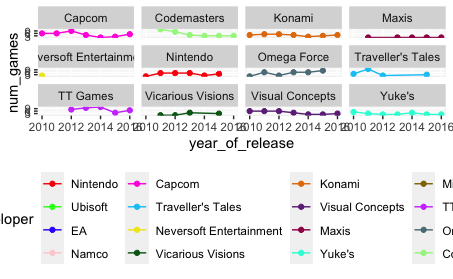

```r
game_sales %>%
  #filter(genre == "") %>%
  filter(year_of_release >= 2010) %>%
  filter(!developer %in% c("EA", "Ubisoft")) %>%
  group_by(developer, year_of_release) %>%
  summarise(num_games = n()) %>%
  ungroup() %>%
  ggplot() +
  aes(x = year_of_release, y = num_games, colour = developer) +
  geom_line() +
  geom_point() +
  scale_colour_manual(values = developer_colour_scheme) +
  theme(legend.position = "bottom") +
  facet_wrap(~ developer, ncol = 4)
```

### theme text + black bg

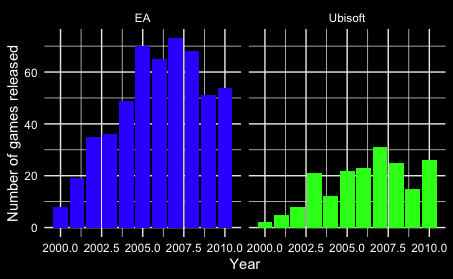

```r
# game releases by developer since 2010

# bar chart
game_sales %>%
  filter(year_of_release %in% c(2000:2010)) %>% # have a year filter for this chart, slider range
  filter(developer %in% c("EA", "Ubisoft")) %>% # HAVE A MULTI-DEVELOPER CHECKBOX
  group_by(developer, year_of_release) %>%
  summarise(num_games = n()) %>%
  ungroup() %>%
  ggplot() +
  aes(x = round(year_of_release, digits = 0), y = num_games, fill = developer) +
  geom_col(show.legend = FALSE) +
  scale_fill_manual(values = developer_colour_scheme) +
  labs(y = "Number of games released", x = "Year", fill = "Developer") +
  facet_wrap(~ developer, ncol = 4) +
  theme_minimal() +
  theme(legend.position = "bottom",
        plot.background = element_rect(fill = "black"),
        legend.text = element_text(colour = "white"),
        legend.title = element_text(colour = "white"),
        plot.title = element_text(colour = "white"),
        strip.text = element_text(colour = "white"),
        axis.text = element_text(colour = "white"),
        axis.title = element_text(colour = "white"))
```

Have a year_slider for all the charts on this page - also include filter for genre and rating?

Use the above plot as rate of publishing by developers

### scatter critic v user scores

Add: scatter sales and user_score / critic_score (input), colour (/label) = developer

New tab? Add something about genre and sales/score - so publisher can pick which genre is successful, then which developers publish in

For developer tab?

Scatter year by user_score / critic_score, bubble size sales, hover-over game name < - for developer tab

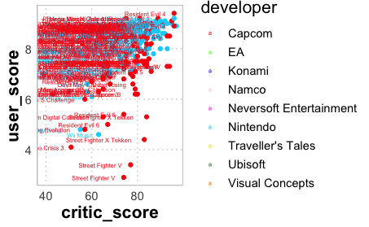

```r
# with name labels
game_sales %>%
  filter(developer %in% c("Nintendo","Capcom")) %>%
  ggplot() +
  aes(x = critic_score, y = user_score, colour = developer, label = name) +
  geom_point(show.legend = FALSE) +
  geom_text(vjust = 0.6, hjust = 1.2, size = 2) +
  scale_colour_manual(values = developer_colour_scheme) +
  theme_simplex()
```

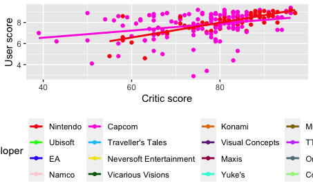

```r
# without name labels, with trend lines
game_sales %>%
  filter(developer %in% c("Nintendo","Capcom")) %>%
  ggplot() +
  aes(x = critic_score, y = user_score, colour = developer) +
  geom_point() +
  geom_smooth(method = lm, se = FALSE) +
  scale_colour_manual(values = developer_colour_scheme) +
  labs(x = "Critic score", y = "User score") +
  theme(legend.position = "bottom")
```

### sales by developer, total

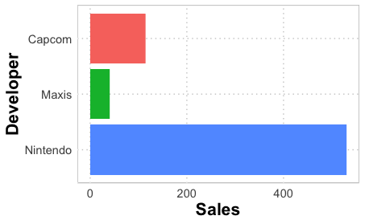

```r
# sales by developer
game_sales %>%
  filter(developer %in% c("Nintendo","Capcom", "Maxis")) %>%
  ggplot() +
  aes(y = reorder(developer, -sales), x = sales, fill = developer) +
  geom_col(show.legend = FALSE) +
  scale_colour_manual(values = developer_colour_scheme) +
  labs(x = "Sales", y = "Developer") +
  theme_simplex()
```

## Set up input lists

### platforms

```r
game_sales %>%
  distinct(platform)
```

| platform |
| --- |
| Wii |
| DS |
| 3DS |
| PS4 |
| PS3 |
| X360 |
| PS2 |
| PS |
| WiiU |
| GC |

[output cut: 6 more lines]

### years

```r
year_list
```

```
 [1] 1988 1989 1990 1991 1992 1993 1994 1995 1996 1997 1998 1999 2000 2001
[15] 2002 2003 2004 2005 2006 2007 2008 2009 2010 2011 2012 2013 2014 2015
[29] 2016
```

#### transform years to int

Make year column to int not dbl:

```r
game_sales %>%
  mutate(year = as.integer(year_of_release), .before = year_of_release)
```

| name | genre | year | year_of_release | publisher | sales | critic_score | user_score | developer | rating | platform |
| --- | --- | --- | --- | --- | --- | --- | --- | --- | --- | --- |
| Wii Sports | Sports | 2006 | 2006 | Nintendo | 82.53 | 76 | 8.0 | Nintendo | E | Wii |
| Mario Kart Wii | Racing | 2008 | 2008 | Nintendo | 35.52 | 82 | 8.3 | Nintendo | E | Wii |
| Wii Sports Resort | Sports | 2009 | 2009 | Nintendo | 32.77 | 80 | 8.0 | Nintendo | E | Wii |
| New Super Mario Bros. | Platform | 2006 | 2006 | Nintendo | 29.80 | 89 | 8.5 | Nintendo | E | DS |
| Wii Play | Misc | 2006 | 2006 | Nintendo | 28.92 | 58 | 6.6 | Nintendo | E | Wii |
| New Super Mario Bros. Wii | Platform | 2009 | 2009 | Nintendo | 28.32 | 87 | 8.4 | Nintendo | E | Wii |
| Mario Kart DS | Racing | 2005 | 2005 | Nintendo | 23.21 | 91 | 8.6 | Nintendo | E | DS |
| Wii Fit | Sports | 2007 | 2007 | Nintendo | 22.70 | 80 | 7.7 | Nintendo | E | Wii |
| Wii Fit Plus | Sports | 2009 | 2009 | Nintendo | 21.79 | 80 | 7.4 | Nintendo | E | Wii |
| Brain Age: Train Your Brain in Minutes a Day | Misc | 2005 | 2005 | Nintendo | 20.15 | 77 | 7.9 | Nintendo | E | DS |

[output cut: 990 more lines]

## tab 1: table output for developers & years filter

to show game names, with developer name, and in order of year released

```r
# most recent games
game_sales %>%
  # add year range filter
  filter(year_of_release >= 2010 &
           year_of_release <= 2016) %>%
  # add multi-select developer input
  filter(developer %in% c("Capcom", "EA", "Namco")) %>%
  select(name,developer,year_of_release) %>%
  arrange(desc(year_of_release), developer, name)
```

[output not shown]

## total sales by developer

```r
game_sales %>%
  group_by(developer) %>%
  summarise(total_sales = sum(sales, na.rm = TRUE)) %>%
  arrange(desc(total_sales)) %>%
  filter(total_sales > 50)
```

| developer | total_sales |
| --- | --- |
| EA | 617.97 |
| Nintendo | 529.90 |
| Ubisoft | 273.51 |
| Capcom | 114.30 |
| Traveller's Tales | 63.39 |
| Visual Concepts | 61.27 |
| Neversoft Entertainment | 60.52 |
| Namco | 59.38 |
| Konami | 55.34 |

#### filter by lowest sales devs

```r
game_sales %>%
  group_by(genre, year_of_release) %>%
  summarise(num_games = n())
```

| genre | year_of_release | num_games |
| --- | --- | --- |
| Action | 1996 | 1 |
| Action | 1998 | 1 |
| Action | 2000 | 5 |
| Action | 2001 | 9 |
| Action | 2002 | 16 |
| Action | 2003 | 26 |
| Action | 2004 | 23 |
| Action | 2005 | 44 |
| Action | 2006 | 27 |
| Action | 2007 | 35 |

[output cut: 179 more lines]

```r
# set up colour schemes
colours_n_dev <- Polychrome::createPalette(N = length(unique(developers_list)), seedcolors = c("#ff0000", "#00ff00","#0000ff"), target = c("normal", "protanope", "deuteranope", "tritanope"))
colours_n_genre <- Polychrome::createPalette(N = length(unique(genres_list)), seedcolors = c("#ffff66", "#00cc99", "#6600ff"), target = c("normal", "protanope", "deuteranope", "tritanope"))
# make colour scheme vectors
developer_colour_scheme <- setNames(colours_n_dev, developers_list)
genre_colour_scheme <- setNames(colours_n_genre, genres_list)
```

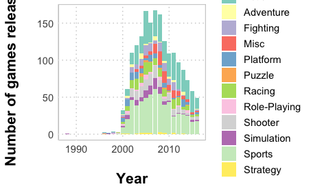

```r
game_sales %>%
  group_by(genre, year_of_release) %>%
  summarise(num_games = n()) %>%
  ggplot() +
    aes(x = year_of_release, y = num_games, fill = factor(genre)) +
      geom_col(position = "stack") +
      scale_fill_brewer(palette = "Set3") +
      #scale_fill_manual(values = genre_colour_scheme) +
      labs(y = "Number of games released\n", x = "\nYear", fill = "Genre") +
      theme(legend.position = "bottom") +
  theme_simplex()
```

this is not that interesting, what about total sales by genre, versus average critic score, with bubble size = number of games

# genre scatter

| genre | count_by_genre | total_sales | avg_critic | avg_user |
| --- | --- | --- | --- | --- |
| Action | 454 | 401.61 | 71.41189 | 7.259471 |
| Adventure | 37 | 25.93 | 70.05405 | 7.672973 |
| Fighting | 110 | 112.65 | 75.45455 | 7.367273 |
| Misc | 101 | 190.18 | 69.46535 | 7.008911 |
| Platform | 90 | 169.48 | 74.68889 | 7.413333 |
| Puzzle | 16 | 28.06 | 78.18750 | 8.081250 |
| Racing | 147 | 165.31 | 73.42857 | 7.236054 |
| Role-Playing | 39 | 30.12 | 74.53846 | 7.912821 |
| Shooter | 143 | 166.79 | 73.20280 | 7.146853 |
| Simulation | 86 | 94.66 | 72.96512 | 7.372093 |

[output cut: 2 more lines]

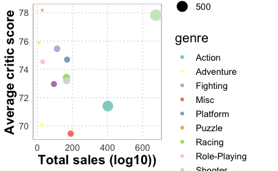

```r
genre_table %>%
  ggplot() +
  aes(x = total_sales, y = avg_critic) +
  geom_point(aes(size = count_by_genre, colour = genre)) +
  #geom_text(aes(label = genre), vjust = 0.3, hjust = -0.2, size = 2, show.legend = FALSE) +
  scale_colour_brewer(palette = "Set3") +
  labs(x = "Total sales (log10))", y = "Average critic score") +
  theme(legend.position = "right") +
  theme_simplex()
```

```r
NA
```

```r
game_sales %>%
      group_by(genre) %>%
      summarise(across(.cols = c(sales, user_score, critic_score),
                        .fns = ~ mean(.x, na.rm=TRUE)))
```

| genre | sales | user_score | critic_score |
| --- | --- | --- | --- |
| Action | 0.8846035 | 7.259471 | 71.41189 |
| Adventure | 0.7008108 | 7.672973 | 70.05405 |
| Fighting | 1.0240909 | 7.367273 | 75.45455 |
| Misc | 1.8829703 | 7.008911 | 69.46535 |
| Platform | 1.8831111 | 7.413333 | 74.68889 |
| Puzzle | 1.7537500 | 8.081250 | 78.18750 |
| Racing | 1.1245578 | 7.236054 | 73.42857 |
| Role-Playing | 0.7723077 | 7.912821 | 74.53846 |
| Shooter | 1.1663636 | 7.146853 | 73.20280 |
| Simulation | 1.1006977 | 7.372093 | 72.96512 |

[output cut: 2 more lines]

# Search table by game name

```r
game_sales %>%
  filter(str_detect(name,"Mario"))
```

| name | genre | year_of_release | publisher | sales | critic_score | user_score | developer | rating | platform |
| --- | --- | --- | --- | --- | --- | --- | --- | --- | --- |
| Mario Kart Wii | Racing | 2008 | Nintendo | 35.52 | 82 | 8.3 | Nintendo | E | Wii |
| New Super Mario Bros. | Platform | 2006 | Nintendo | 29.80 | 89 | 8.5 | Nintendo | E | DS |
| New Super Mario Bros. Wii | Platform | 2009 | Nintendo | 28.32 | 87 | 8.4 | Nintendo | E | Wii |
| Mario Kart DS | Racing | 2005 | Nintendo | 23.21 | 91 | 8.6 | Nintendo | E | DS |
| Super Mario Galaxy | Platform | 2007 | Nintendo | 11.35 | 97 | 8.9 | Nintendo | E | Wii |
| Super Mario 3D Land | Platform | 2011 | Nintendo | 10.81 | 90 | 8.4 | Nintendo | E | 3DS |
| New Super Mario Bros. 2 | Platform | 2012 | Nintendo | 9.90 | 78 | 7.2 | Nintendo | E | 3DS |
| Super Mario Galaxy 2 | Platform | 2010 | Nintendo | 7.51 | 97 | 9.1 | EA | E | Wii |
| Mario Kart 8 | Racing | 2014 | Nintendo | 7.09 | 88 | 9.1 | Nintendo | E | WiiU |
| Super Mario Sunshine | Platform | 2002 | Nintendo | 6.31 | 92 | 8.6 | Nintendo | E | GC |

[output cut: 9 more lines]

# Custom ggplot theme for simplex

```r
theme_simplex <- function() {
  theme_minimal() +
    theme(
    # add border 1)
    panel.border = element_rect(colour = "white", fill = NA),

    # color background 2)
    panel.background = element_rect(fill = "white"),

    # modify grid 3)
    panel.grid.major.x = element_line(colour = "grey80", linetype = 3, size = 0.5),
    panel.grid.minor.x = element_blank(),
    panel.grid.major.y =  element_line(colour = "grey80", linetype = 3, size = 0.5),
    panel.grid.minor.y = element_blank(),

    # modify texts
    plot.title = element_text(colour = "indianred", face = "bold", family = "Arial", size = 20),
    legend.title = element_text(family = "Arial", size = 16),
    legend.text = element_text(family = "Arial", size = 11),
    axis.title = element_text(face = "bold", family = "Arial", size = 16),
    axis.text = element_text(family = "Arial", size = 11),
    strip.text.x = element_text(size = 12, face = "bold"),
    #axis.ticks = element_line(colour = "steelblue")
  )
}
```